# Machine Learning Assignment

thendricco

## Executive Summary

Using devices such as Jawbone Up, Nike FuelBand, and Fitbit it is now possible to collect a large amount of data about personal activity relatively inexpensively. These type of devices are part of the quantified self movement - a group of enthusiasts who take measurements about themselves regularly to improve their health, to find patterns in their behavior, or because they are tech geeks. One thing that people regularly do is quantify how much of a particular activity they do, but they rarely quantify how well they do it.

The aim of this report will be to use use data from accelerometers placed on the belt, forearm, arm, and dumbell of six participants to predict and classify how well they were doing the exercise.

## Environment Settings

The following libraries are used.

```r
library(caret)
```

```r
library(corrplot)
library(kernlab)
library(knitr)
library(randomForest)
```

## Loading and Preparing the data

The 2 csv files containing the training and test data were downloaded into a data folder in the working directory.

## Loading the Training Data

```r
data_training <- read.csv("./data/pml-training.csv", na.strings= c("NA",""," "))
```

Substantial NA values were found and caused noise for the model. Therefore a decision to remove the columns and NA values was made.

```r
# clean the data by removing columns with NAs etc
data_training_NAs <- apply(data_training, 2, function(x) {sum(is.na(x))})
data_training_clean <- data_training[,which(data_training_NAs == 0)]

# remove identifier columns such as name, timestamps etc
data_training_clean <- data_training_clean[8:length(data_training_clean)]
```

## Creating the model

The data set is split up to 70% training and 30% cross-validation.

```r
# split the cleaned testing data into training and cross validation
inTrain <- createDataPartition(y = data_training_clean$classe, p = 0.7, list = FALSE)
training <- data_training_clean[inTrain, ]
crossval <- data_training_clean[-inTrain, ]
```

A random forest model is chosen to predict the classification and subsequently a plot is drawn to see the relationships.

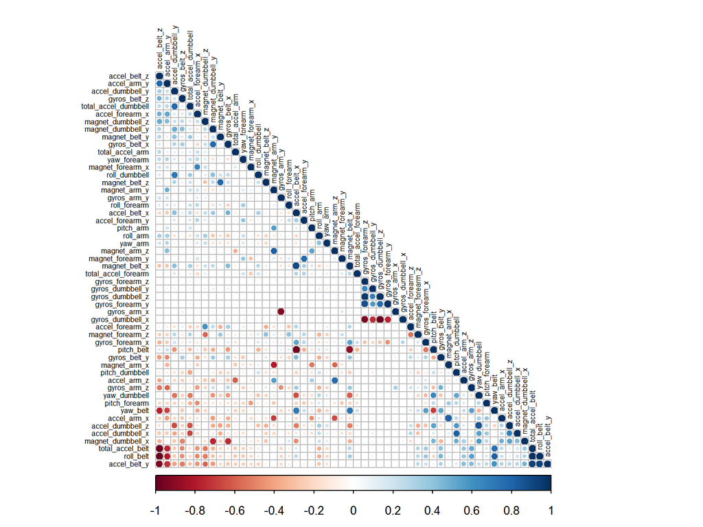

```r
# plot a correlation matrix
correlMatrix <- cor(training[, -length(training)])
corrplot(correlMatrix, order = "FPC", method = "circle", type = "lower", tl.cex = 0.5,  tl.col = rgb(0, 0, 0))
```

- The dark red colours indicate a highly negative relationship.
- The dark blue colors indicate a highly positive relationship.

Subsequently, fit the model predict using everything else as predictor.

```r
# fit a model to predict the classe using everything else as a predictor
model <- randomForest(classe ~ ., data = training)
model
```

```
##
## Call:
##  randomForest(formula = classe ~ ., data = training)
##                Type of random forest: classification
##                      Number of trees: 500
## No. of variables tried at each split: 7
##
##         OOB estimate of  error rate: 0.52%
## Confusion matrix:
##      A    B    C    D    E  class.error
## A 3904    1    0    0    1 0.0005120328
## B   16 2638    4    0    0 0.0075244545
## C    0   16 2380    0    0 0.0066777963
## D    0    0   22 2228    2 0.0106571936
## E    0    0    4    6 2515 0.0039603960
```

## Cross-validation

The model is then used to classify the 30% of the data. Results are placed in a confusionMatrix to determine the accuracy.

```r
# crossvalidate the model using the remaining 30% of data
predictCrossVal <- predict(model, crossval)
confusionMatrix(crossval$classe, predictCrossVal)
```

```
## Confusion Matrix and Statistics
##
##           Reference
## Prediction    A    B    C    D    E
##          A 1674    0    0    0    0
##          B    9 1129    1    0    0
##          C    0    3 1021    2    0
##          D    0    0    5  959    0
##          E    0    0    1    0 1081
##
## Overall Statistics
##
##                Accuracy : 0.9964
##                  95% CI : (0.9946, 0.9978)
##     No Information Rate : 0.286
##     P-Value [Acc > NIR] : < 2.2e-16
##
##                   Kappa : 0.9955
##  Mcnemar's Test P-Value : NA
##
## Statistics by Class:
##
##                      Class: A Class: B Class: C Class: D Class: E
## Sensitivity            0.9947   0.9973   0.9932   0.9979   1.0000
## Specificity            1.0000   0.9979   0.9990   0.9990   0.9998
## Pos Pred Value         1.0000   0.9912   0.9951   0.9948   0.9991
## Neg Pred Value         0.9979   0.9994   0.9986   0.9996   1.0000
## Prevalence             0.2860   0.1924   0.1747   0.1633   0.1837
## Detection Rate         0.2845   0.1918   0.1735   0.1630   0.1837
## Detection Prevalence   0.2845   0.1935   0.1743   0.1638   0.1839
## Balanced Accuracy      0.9973   0.9976   0.9961   0.9985   0.9999
```

The model yielded a 99.6% prediction accuracy.

## Predictions

The testing data is then loaded. Which the model is then use to predict the 20 results.

```r
# apply the same treatment to the final testing data
data_test <- read.csv("./data/pml-testing.csv", na.strings= c("NA",""," "))
data_test_NAs <- apply(data_test, 2, function(x) {sum(is.na(x))})
data_test_clean <- data_test[,which(data_test_NAs == 0)]
data_test_clean <- data_test_clean[8:length(data_test_clean)]

# predict the classes of the test set
predictTest <- predict(model, data_test_clean)
predictTest
```

```
##  1  2  3  4  5  6  7  8  9 10 11 12 13 14 15 16 17 18 19 20
##  B  A  B  A  A  E  D  B  A  A  B  C  B  A  E  E  A  B  B  B
## Levels: A B C D E
```